# DRAFT: The SDGs as a network of targets characterized by challenges, subjects and actions

Peter Søgaard Jørgensen

25 September 2015

# 1 ABSTRACT

These days the world’s governments meet to mark the adoption of a set of global goals for sutainable development of humanity and the environment, the Sustainable Development Goals (SDGs). The SDGs can be seen as following up on previous international efforts on how humans can continue to prosper on the planet while maintaining a flurising and safe environment. In the UN system this effort dates back to the Stockholm Convention on the Human Environment of 1972 and, most recently, the SDGs’ immediate predecessor the Millennuim Development Goals (MDGs). Here I conduct a keyword-based network analysis of target to target linkages between **126** SDG targets. I identify and map keywords under content categories such as target challenges, subjects, actions, derived properties, instruments and conditionalities. I use these keywords to construct and compare a number of target and goals based networks with regard to structure, including connectivity, sub-networks and unifying keywords.

The analysis conducted in this paper, is to my knowledge the most detailed formal network analysis of the Sustainable Development Goals as a system of targets. While there is room to continue to advance application of network analysis to the SDGs, e.g. by including *means of implementation* targets, incorporating thesauruses to identify synonyms and implement a hierarchical analysis of keywords, the analysis provides a useful starting point for these more advanced applications and, more importantly, achieves a concise synthesis and helpful visualizations of the interconnections among more than 100 of the SDG targets. The present analysis yields multiple novel insights to the SDGs a system of targets.

- First and foremost, I show that connections between targets and goals become increasingly evident when targets are characterized, not only by the topical challenges they address (which has dominated previous approaches), but also by the subjects they address and the nature of the actions they propose.
- Secondly and more specifically, this multifaceted analysis increases connections across genereal goal themes, and thus helps avoid treating the SDGs as a fragemented agenda of disparate social, economic, environmental and resource topics.
- Third, the analysis identifies the central targets that are connected to targets under other goals and therefore require coordination with other planned actions.
- Fourth and finally, the analysis identifies a number of keyword topics that if addressed succesfully across targets will help achieve a high proportion of the SDGs, such as issues of access, women, resources and finance.

# 2 INTRODUCTION

## 2.1 The history of the SDGS

These days the world’s governments meet to mark the adoption of a set of global goals for sutainable development of humanity and the environment, the Sustainable Development Goals (SDGs). The SDGs can be seen as following up on previous international efforts on how humans can continue to prosper on the planet while maintaining a flurising and safe environment. In the UN system this effort dates back to the Stockholm Convention on the Human Environment of 1972 and, most recently, the SDGs’ immediate predecessor the Millennuim Development Goals (MDGs).

## 2.2 The SDGs are different from the MDGs

The SDGs differ from the MDGs in a number of ways. First, by targeting both developing and developed countries. Secondly, by having been drafted and negotiated in a comprehensive and much more open and inclusive process. And finaly, by their size. Partially as a result of the inclusive negotiation format, the SDGs have become very comprehensive and cover 17 general topics, composed of 169 targets.

## 2.3 The size of the SDGs mean that an overview is hard to get, but increasingly important

Coherently understanding the content and connections in the complex 169 target system is important for an effective communication of the SDGs to the public and for effectively planned and prioritized efforts so that national governements and other parties can deliver on the targets. Yet, a coherent systems understanding of the SDGs is made more difficult by their size and scope, e.g. compared to the much smaller MDGs (eight goals) or other more focused multilaterial agreements such as the 20 Aichi biodiversity targets.

## 2.4 Previous system approaches to the SDGs

The SDGs have been subject to a couple of analyses aiming to characterize and visualize the system of goals and targets. These analyses add to a long list of papers proposing, reviewing and discussing the approach and content of the SDGs (Griggs et al. 2014a, 2014b, ICSU & ISSC 2015, Haijer et al. 2015, Carroll and Jørgensen et al. 2014, Lu et al. 2015). The system analyses span from network-type analyses aiming to show how targets build thematic connections between goals (Le Blanc 2015a, 2015b), to classification analyses aiming to characterize the composition of goals and targets in relation to broad topics such as the three pillars of sustainable development (economic, environmental and social develoment) (Cutter et al. 2015).

## 2.5 What might a network analysis reveal?

A network analysis can reveal which targets are dependent on one another and what properties are important in connecting the targets. In particular, a network based analsis may also reveal and help visualize clusters of tartgets and goals that may need to be achieved in close coordination. Similarly, a network analysis can reveal topics that are isolated. Thus a network analysis will help understand how integrated the SDGs are or whether targets cluster together in groups that focus on e.g. enviornmental, economic or social aspects.

## 2.6 More in-depth discussion of Le Blanc.

Le Blanc (2015) characterized the general thematic content of 107 SDG targets, excluding targets focusing on “means of implementation”. Le Blanc found that goals were differentially interconntected through the content of their individual targets. In particular, targets of the sustainable consumption and production goal (goal 12), the inequality goal (10), the poverty goal (1), as well as the goal on economic growth and jobs (8), were connected to the themes of 10 or more goals. In contrast, targets under the oceans (14), infrastructre (9) and energy (7) goals, were only thematically connected to two or three other goals. Le Blanc’s analysis thus identifies the targets and goals that are particularly likely to generallly influence themes of other goals.

## 2.7 Advancement of Le Blanc 2015

The analysis of Le Blanc is the most comprehensive analysis of the SDGs as an interconnected system to date. At the same time, it leaves some room for complementary approaches. More specifically, there is still a need to, (1) characterize the system vy target-to-target based connections (instead of target to goal connections); (2) understand how targets and goals are connected to each other through the specific actions proposed and challenges addressed (instead of the general themes of the goals); (3) compare other types of connections in the systems, for example the subjects they aim to affect.

## 2.8 Aims of the study

Here I conduct a keyword-based network analysis of target to target linkages between **126** SDG targets. I identify and map keywords under content categories such as target challenges, subjects, actions, derived properties, instruments and conditionalities. I use these keywords to construct and compare a number of target and goals based networks with regard to structure, including connectivity, sub-networks and unifying keywords.

Despite various potential pitfalls of keyword based analyses, such as implying links between identical words with differnet contextual meanings and omission of implicit linkages between targets, the formality of this type of analysis yields a higher degree of methodological transparency and flexibility. The analyses provide a broader understanding of the complex network constituted by SDGs and may idenfity new, unappreciated linkages. This is an important contribution to the understanding of the SDGs, since each linkage may in the end show itself as a candidate leverage point for in 2030 to deliver succesfully on the unprecedented ambitious SDG agenda.

# 3 METHODS

## 3.2 SCOPE AND LIMITATIONS OF KEYWORD MAPPING / CODING

While keyword mapping/coding is a powerful tool to characterize and visualize long text documents (**e.g. WordCloud**), it also have some limitations and potential pitfalls. While an analysis of this type is always some degree of interpretation, a number of steps were implemented to try and limit the effect of these pitfalls:

1. The mapping method is vulnerable to implying links between identical language and terminology with different meanings or similar meaning, but unrelated in terms of implementation context. Such as e.g. production or productivity. However these connections may have some use in terms of thinking more deeply about the actions in a systems-oriented approach. E.g. thinking deeply about approaches to productivity or what productivity means in the era of the post-2015 agenda.
2. Words with **multiple meanings** were attempted coded to reflect those different meanings. One example is the word “banks” which appeared both in the context of biology, finance and technology. In this case banks was specified as “biological banks”, “technological banks” and “financial banks” and the general term “banks” was avoided in the keyword mapping. The words include terms with specific and more general/meta-property insights, the latter such as “care”, “protection”.

To avoid initial duplication in keywords and increase consistency and compatiblity of mapped keywords, conventions were applied to turn target text words into keywords. Some examples of applied rules, are:

- Pronouns were substituted with nouns.
- Word negations such as Un- or I- were substituted with the positive form of word, where possible.
- In the subject category, adjectives are nested within subject and not mapped as a root, except in rare cases mapped when judged to make sense as a single mapping.

## 3.3 SPECIFIC MAPPING APPROACH

### 3.3.1 MAPING CATEGORIES AND STRATEGIES

We mapped the following categories in the target texts. “Challenges”, “Subjects”, “Instruments and Conditions”, “Actions” and “Properties”. Mapped keywords can be members of more than one category in the target text. When there was any doubt about what category a term should be mapped to, I mapped the term to all of those categories. I ran analyses with and without words that had multi-group memberships (example of a **tough target:** 12_4).

Two strategies were applied for converting target text into keywords **1) Root mapping**, which usually involved maping one keyword to a target text word (but see below) and **2) Composite mapping** which included combinations of two or more words linked in the target text. All root mappings figure in the composite mapping method and the composite mapping method also inclue more unique word combinations, but runs the risk of weighting similar targets too much because of these extra keywords.

#### 3.3.1.1 MAPPING ROOT TERMS

A root term mapping represents the basic word components. Usually there cannot be more mappings than there are keywords identified in the term combination. When the single word of the term combination makes sense that word is mapped. When one of the single words looses its meaning when it stands alone, the combination with its other root word is mapped. In the root mapping some composite words such as “wastewater” can be decomposed into their components - waste and water (see e.g. 6_3).

- Some root components of challenges may also be mapped as properties.
- Work environment not decomposed into “work” and “environment”, but mapped as “work environment” and “work”. See 8_8.
- Some words were turned into multiple roots, such as e.g. “fisheries” (e.g. in 14.6), which was mapped to both “fish” and “fisheries” root keywords and “overfishing” was mapped to “fisheries”, “fish” and “overharvesting”. “Fish” on the other hand was only mapped as “fish” and not “fisheries” (since fisheries always relate to fish, but not vice versa).

#### 3.3.1.2 COMPOSITE MAPPING

In addition to the root mappings, the composite mapping strategy also mapped combinations of two or more words together. For example, “natural resources” was mapped as both “natural resources”, “nature”, and “resouces”. This strategy can potentially identified more nuanced connections between targes than the root mapping strategy.

#### 3.3.1.3 MAPPING DERIVED TERMS

- A derived word column identifies mappings to a term that are beyond the term itself. The potential benefit of mapping a set of such derived terms is illustrated by the dillemma of wheter to illustrate the link between ecosystems and oceans goals to natural ressources via the common word nature. I ran analyses with and without these derived terms.
- In target 14.6 the following derived terms were mapped.
  - fisheries capacity <- [overcapacity]
  - trading <- [World Trade Organization]

#### 3.3.1.4 DEFINITIONS AND EXAMPLES OF MAPPINGS

The following definitions of keyword categories and examples of mapping strategies illustrate the approach with a couple of targets as examples:

**CHALLENGES**: The topic addressed by the target.

*“12.8 By 2030, ensure that people everywhere have the **relevant information and awareness for sustainable development and lifestyles in harmony with nature**”*

- Root mappings:
  - nature <- [nature]
  - harmony <- [harmony]
  - development <- [development]
  - information <- [information]
  - lifestyle <- [lifestyle]
  - awareness <- [awareness]
  - (sustainability) <- [sustainable]
    - sustainability is consistently omitted from the challenges category and instead included in the property category.
- Additional composite mappings:
  - development information <- [information] x [development]
  - development awareness <- [awareness] x [development]
  - lifestyle information <- [information] x [lifestyles]
  - lifestyle awareness <- [awareness] x [lifestyles]

**THE PROPERTY CATEGORY IDENTIFIES DERIVED CHALLENGES OR “META-CHALLENGES”**:

Properties describe the context or and attribute of the challenge. Properties were mapped through two complementary methods (1) through preposition links, and (2) through adjectives. Not all words in front of prepositions were scored as a property if they embodied one of the central and specific challenges of a target - such as “genetic diversity”, “premature mortality”. Properties mappings often overlap with *challenges* mappings and overlapping and exclusive sets of each were run.

**SUBJECTS**: The subject category identifies persons, geographical, biological and organizational scales and units affected or targeted by a target. I ran an analysis including and excluding biological subjects as they were also usually mapped as keywords in the challenge category.

“*12.8 By 2030, ensure that **people everywhere** have the relevant information and awareness for sustainable development and lifestyles in harmony with nature*”

- all <- [people everywhere]
- people <- [people everywhere]

**ACTIONS**: The verb characterizing the nature of the action - e.g. in target 12.8:

For nested actions - e.g. “encourage to adopt”, “encourage to integrate”, the nested action was mapped both as a property and an action. In some cases actions can be included as aims/challenges if they have specific/technical meaning in the topical context, such as target 6.6 “protect and restore” included as “ecosystem restoration” and “ecosystem protection”. (*Check when Actions (verbs) are coded into challenges. E.g. “regulate”, “protect”, “conserve”, “restore”, “prohibit”*).

“*12.8 By 2030, **ensure** that people everywhere have the relevant information and awareness for sustainable development and lifestyles in harmony with nature*”

- ensuring <- [ensure]

*PREPOSITION MAPPING*: Often an important “property”" of the action or challenge is linked to the root challenge through a preposition (such as “to”).

1. Examples include: “access to”, “equal rights to”
2. “of” and “for” prepositions often identify property mappings that are more specific than e.g. “to” mappings.
3. Examples of preoposition mappings from target 12.8.
   - harmony <- [harmony]
   - information <- [information]
   - awareness <- [awareness]

*ADJECTIVES MAPPING*: A second way properties can be identified is as an adjective of a term, such as “hazardous chemicals”, the property is “hazard”.

- Sustainability as an example from target 12.8:
  - sustainability <- [sustainable development/lifestyles]

“*14.6 By 2020, prohibit certain forms of fisheries subsidies which contribute to overcapacity and overfishing, eliminate subsidies that contribute to **illegal, unreported and unregulated** fishing and refrain from introducing new such subsidies, recognizing that **appropriate and effective** special and differential treatment for developing and least developed countries should be an integral part of the World Trade Organization fisheries subsidies negotiation*”

- legality <- [illegal]
- reporting <- [unreported]
- regulation <- [unregulated]
- appropriateness <- [appropriate]
- effectiveness <- [effective]
- special status <- [special treatment]
- differentiation <- [differential treatment]

**INSTRUMENTS**: Istruments mention a tool (specific or general) to achieve a target. Broad instruments were also included in the challenges category, marked in *InsturmentAsChallenge* column. Run with and without these keywords in challenges category. Because of the difficulty of sometimes distinguishing betweeen conditions and instruments (i.e. barriers and tools),they were lumped in the same category in the final analysis.

*“14.6 By 2020, prohibit certain forms of fisheries subsidies which contribute to overcapacity and overfishing, eliminate subsidies that contribute to illegal, unreported and unregulated fishing and refrain from introducing new such subsidies, recognizing that appropriate and effective special and differential treatment for developing and least developed countries should be an integral part of the **World Trade Organization fisheries subsidies negotiation**”*

- negotiation <- [negotiation]
- WTO <- [WTO]

**CONDITIONS**: Mapping of a phrase in the target text implying conditionality of the action.

“*14.6 By 2020, prohibit certain forms of fisheries subsidies which contribute to overcapacity and overfishing, eliminate subsidies that contribute to illegal, unreported and unregulated fishing and refrain from introducing new such subsidies, **recognizing that appropriate and effective special and differential treatment for developing and least developed countries** should be an integral part of the World Trade Organization fisheries subsidies negotiation*”

- special treatment <- [special] x [treatment]
- differential treatment <- [differential] x [treatment]
- treatment <- [treatment]
- LDCs <- [least developed countries]
- devloping countries <- [developing countries]

## 3.4 NETWORK ANALYSIS

### 3.4.1 NETWORK TYPES AND CONSTRUCTION

| Network# | Type | Name | Description |
| --- | --- | --- | --- |
| 1 | MAIN | RootDerived | Root mappings with derived terms (categories separated) |
| 2 | - | RootOnly | Root mappings without derived terms (categories separated) |
| 3 | - | RootOnlyGoal17 | Root mappings without derived terms with Goal 17 (categories separated) |
| 4 | - | RootOnlyMerged | Root mappings without derived terms (categories merged) |
| 5 | - | CompositeDerived | Composite mappings with derived terms (categories separated) |
| 6 | - | CompositeOnly | Composite mappings without derived terms (categories separated) |
| 7 | SUBJECT | SubjectAll | All subject mappings (without derived terms, goal 1-16) |
| 8 | - | SubjectHuman | All subject mappings excluding non-human organisms (without derived terms, goal 1-16) |
| 9 | CHARACTER | ActionPropertyTool | Action, property and instrument/condition mappings (without derived terms, goal 1-16) |
| 10 | - | Action | Action mappings (without derived terms, goal 1-16) |
| 11 | - | Property | Property mappings (without derived terms, goal 1-16) |
| 12 | - | Tool | Instrument and condition mappings (without derived terms, goal 1-16) |
| 13 | CHALLENGE | ChallengeRootDerived | Root challenge mappings with derived terms (goal 1-16) |
| 14 | - | ChallengeRootOnly | Root challenge mappings without derived terms (goal 1-16) |
| 15 | - | ChallengeCompositeDerived | Composite challenge mappings with derived terms (goal 1-16) |
| 16 | - | ChallengeCompositeOnly | Composite challenge mappings without derived terms (goal 1-16) |
| 17 | - | ChallengeRootNarrow | Root challenge mappings without derived terms and without shared property and instrument mappings (goal 1-16) |

**Table 1** The 17 variations of goal and target-level networks. The *main* type uses all keyword categories, other types uses a subset. In particular, the *subject* type networks are based the subjects of the target, the *character* type networks on the actions, properties and tools of the targets, and the *challenge* category on the challenges addressed by the target.

### 3.4.2 VISUALIZATION

For visualization of the network I used a Fruchterman Reingold layout with 10.000 iterations. For visualization of connection strength I used the squared edge weight scaled with a constant (C) to enhance interpretability. `plot(g,edge.width=(E(pr$proj2)$weight^2)/C)`

### 3.4.4 SUB-NETWORK/COMMUNITY MEMBERSHIP

I used the walktrap community function `walktrap.community()` to compute sub-network membership. “This function tries to find densely connected subgraphs, also called communities in a graph via random walks. The idea is that short random walks tend to stay in the same community.”

### 3.4.5 NETWORK METRICS

#### 3.4.5.1 Distance metrics

I computed the mean distance and the mean longest distance in the networks using the `mean_distance()` and `eccentricity()` functions.

#### 3.4.5.2 Modularity metrics

I calculated modularity of the identified walktrap communities using the `modularity()` function.

#### 3.4.5.3 Assortativity metrics

I calculated the assortativity, i.e. the degree to which a network was structured according to goals or goal themes, using the `assortativity_nominal()` function.

#### 3.4.5.4 Centrality metrics

I calculated four network centrality metrics quantifying the degree to which a network is influenced by the vertex level centrality metrics. I used eigenvector centrality `centr_eigen()`, betweenness centrality `centr_betw()`, degree centrality `centr_degree()` and closeness centrality `centr_clo()`.

### 3.4.6 Vertex and edge metrics

Vertices (targets or goals) were characterized by their number of edges, the number of goals they connected to and the proportion of edges that went to another goal than its own. Edges (keywords) were characterized by the number of targets and goals they connected to.

# 4 RESULTS

## 4.1 NETWORK METRICS

### 4.1.1 GOALS-LEVEL NETWORKS

#### 4.1.1.1 Mean distance and eccentricity

Goals-based networks were tighly connected. In the MAIN network type, drawing on all keyword categories, nodes in the goals-based networks were directly connected to all other goals [**table 2**, mean distance and eccentricity = 1.0].

Sub-type networks were also highly connected with nine out of eleven mean distances less than 1.2 (two networks - #29 and #34 in Table 2 - with distances between 3.1 and 3.2). These results were confirmed by eccentricity metrics. Eccentricity metrics for the two *subject* networks was 1.13, while *character* and *challenge* networks varied between 1.13 (n=1) and 1.87 (n[>1.13]=8).

#### 4.1.1.4 Centrality

Network centrality was 0 for all main networks (since all nodes were connected to each other). Among the sub-networks, centrality metrics were generally highest for single *character* networks (networks 27-29) and lowest for the subject networks (network 24 and 25).

### 4.1.2 TARGETS-LEVEL NETWORKS

Overall target-level networks showed higher variation within metrics and in the relative ranking of networks across metrics.

#### 4.1.2.1 Mean distance and eccentricity

The *main* networks had the lowest distance and eccentricity scores (**table 4**). Subject networks and the combined *character* network (network 7-9) had the smallest distance scores among the sub-categories, and the other *character* netowrks and *challenge* networks the highest distances. This pattern was mirrored, but less pronounced for eccentricity metrics (**table 4**).

#### 4.1.2.3 Assortativity

Assortatitivy was neglitiable or negative for all *character* and *subject* networks (max=0.01) and ranged between 0.016 and 0.03 for the *main* networks. In comparison, *challenge* network assortativity ranged between 0.10 and 0.16, indicating that challenges were most asociated with goal number and goal category (table 4).

## 4.3 UNIFYING KEYWORDS

Four keywords occurred in more than 10 goals (Fig. 4): *subject* all (15), *subject* national (13), *property* accessibility (12) and *action* ensuring (12). Subject keywords were dominated by keywords signalling universality of the goals, e.g. all, people (9 goals) and global (9) and a focus on women (8). Top character keywords signalled a focus on accessibility (12 goals) and (not surprisingly) sustainability (8 goals) and were otherwise represented by action keywords including equal representation of promoting (9) and reduction (9). Occurrence of op keywords often overlapped in some of the central targets and complemented each other by covering different parts of the more peripheral target network (e.g. **fig 5**).

# 5 TABLES

#### 5.0.0.1 MAIN NETWORK TABLES

|  | Network | MeanD | LongD | Com# | Modul. | Ass. Goal | Ass. Cat. |
| --- | --- | --- | --- | --- | --- | --- | --- |
| 18 | RootDerived-Goal | 1.000 | 1.000 | 2 | -0.031 | -0.067 | -0.067 |
| 19 | RootOnly-Goal | 1.000 | 1.000 | 2 | -0.020 | -0.067 | -0.067 |
| 20 | RootOnlyGoal17-Goal | 1.000 | 1.000 | 2 | -0.022 | -0.062 | -0.062 |
| 21 | RootOnlyMerged-Goal | 1.000 | 1.000 | 2 | -0.031 | -0.067 | -0.067 |
| 22 | CompositeDerived-Goal | 1.000 | 1.000 | 2 | -0.031 | -0.067 | -0.067 |
| 23 | CompositeOnly-Goal | 1.000 | 1.000 | 2 | -0.020 | -0.067 | -0.067 |
| 24 | SubjectAll-Goal | 1.008 | 1.125 | 2 | -0.029 | -0.067 | -0.064 |
| 25 | SubjectHuman-Goal | 1.008 | 1.125 | 2 | -0.029 | -0.067 | -0.064 |
| 26 | ActionPropertyTool-Goal | 1.008 | 1.125 | 2 | -0.028 | -0.067 | -0.064 |
| 27 | Action-Goal | 1.083 | 1.500 | 2 | -0.009 | -0.068 | -0.080 |
| 28 | Property-Goal | 1.150 | 1.750 | 2 | -0.002 | -0.069 | -0.074 |
| 29 | Tool-Goal | 3.171 | 1.733 | 15 | -0.082 | -0.090 | -0.100 |
| 30 | ChallengeRootDerived-Goal | 1.075 | 1.562 | 2 | -0.006 | -0.067 | -0.045 |
| 31 | ChallengeRootOnly-Goal | 1.075 | 1.562 | 2 | -0.006 | -0.067 | -0.045 |
| 32 | ChallengeCompositeDerived-Goal | 1.075 | 1.562 | 3 | -0.026 | -0.067 | -0.045 |
| 33 | ChallengeCompositeOnly-Goal | 1.075 | 1.562 | 3 | -0.029 | -0.067 | -0.045 |
| 34 | ChallengeRootNarrow-Goal | 3.133 | 1.875 | 4 | 0.038 | -0.076 | -0.010 |

**Table 2** Goal level network metrics, including mean distance, eccentricity, number of walktrap communities, community modularity, and assortativity of the network according the goals and goal categories. See methods for further explanation of metrics.

|  | Network | Eigen | Betw. | Degree | Close. |
| --- | --- | --- | --- | --- | --- |
| 18 | RootDerived-Goal | 0.000 | 0.000 | 0.000 | 0.000 |
| 19 | RootOnly-Goal | 0.000 | 0.000 | 0.000 | 0.000 |
| 20 | RootOnlyGoal17-Goal | 0.000 | 0.000 | 0.000 | 0.000 |
| 21 | RootOnlyMerged-Goal | 0.000 | 0.000 | 0.000 | 0.000 |
| 22 | CompositeDerived-Goal | 0.000 | 0.000 | 0.000 | 0.000 |
| 23 | CompositeOnly-Goal | 0.000 | 0.000 | 0.000 | 0.000 |
| 24 | SubjectAll-Goal | 0.008 | 0.000 | 0.008 | 0.017 |
| 25 | SubjectHuman-Goal | 0.008 | 0.000 | 0.008 | 0.017 |
| 26 | ActionPropertyTool-Goal | 0.008 | 0.000 | 0.008 | 0.017 |
| 27 | Action-Goal | 0.078 | 0.004 | 0.083 | 0.152 |
| 28 | Property-Goal | 0.132 | 0.016 | 0.150 | 0.256 |
| 29 | Tool-Goal | 0.344 | 0.122 | 0.367 | 0.201 |
| 30 | ChallengeRootDerived-Goal | 0.071 | 0.003 | 0.075 | 0.139 |
| 31 | ChallengeRootOnly-Goal | 0.071 | 0.003 | 0.075 | 0.139 |
| 32 | ChallengeCompositeDerived-Goal | 0.071 | 0.003 | 0.075 | 0.139 |
| 33 | ChallengeCompositeOnly-Goal | 0.071 | 0.003 | 0.075 | 0.139 |
| 34 | ChallengeRootNarrow-Goal | 0.301 | 0.035 | 0.250 | 0.145 |

**Table 3** Four goal level network centrality metrics based on eigenvectors, betweenness, degree and closeness. See methods for further explanation of metrics.

| Network | MeanD | LongD | Com# | Modul. | Ass. Goal | Ass. Cat. |
| --- | --- | --- | --- | --- | --- | --- |
| RootDerived-Target | 1.561 | 2.150 | 4 | 0.114 | 0.023 | 0.056 |
| RootOnly-Target | 1.586 | 2.187 | 6 | 0.131 | 0.018 | 0.037 |
| RootOnlyGoal17-Target | 1.589 | 2.230 | 4 | 0.157 | 0.030 | 0.048 |
| RootOnlyMerged-Target | 1.563 | 2.150 | 4 | 0.115 | 0.017 | 0.036 |
| CompositeDerived-Target | 1.561 | 2.150 | 4 | 0.114 | 0.023 | 0.056 |
| CompositeOnly-Target | 1.586 | 2.187 | 6 | 0.131 | 0.018 | 0.037 |
| SubjectAll-Target | 7.739 | 3.204 | 12 | 0.205 | 0.011 | 0.020 |
| SubjectHuman-Target | 5.726 | 3.176 | 14 | 0.180 | -0.005 | -0.009 |
| ActionPropertyTool-Target | 3.839 | 3.028 | 7 | 0.276 | 0.002 | 0.003 |
| Action-Target | 11.952 | 4.607 | 14 | 0.496 | 0.000 | 0.026 |
| Property-Target | 13.531 | 4.150 | 16 | 0.339 | -0.002 | 0.003 |
| Tool-Target | 11.592 | 5.556 | 16 | 0.174 | -0.033 | -0.062 |
| ChallengeRootDerived-Target | 7.858 | 3.271 | 14 | 0.272 | 0.103 | 0.238 |
| ChallengeRootOnly-Target | 7.989 | 3.514 | 10 | 0.260 | 0.105 | 0.205 |
| ChallengeCompositeDerived-Target | 7.856 | 3.271 | 14 | 0.270 | 0.102 | 0.236 |
| ChallengeCompositeOnly-Target | 7.976 | 3.477 | 17 | 0.256 | 0.103 | 0.203 |
| ChallengeRootNarrow-Target | 44.244 | 3.981 | 42 | 0.425 | 0.163 | 0.312 |

**Table 4** Target level network metrics, including mean distance, eccentricity, number of walktrap communities, community modularity, and assortativity of the network according the goals and goal categories. See methods for further explanation of metrics.

| Network | Eigen | Betw. | Degree | Close. |
| --- | --- | --- | --- | --- |
| RootDerived-Target | 0.412 | 0.017 | 0.341 | 0.353 |
| RootOnly-Target | 0.424 | 0.017 | 0.319 | 0.311 |
| RootOnlyGoal17-Target | 0.434 | 0.017 | 0.321 | 0.314 |
| RootOnlyMerged-Target | 0.406 | 0.015 | 0.306 | 0.304 |
| CompositeDerived-Target | 0.412 | 0.017 | 0.341 | 0.353 |
| CompositeOnly-Target | 0.424 | 0.017 | 0.319 | 0.311 |
| SubjectAll-Target | 0.576 | 0.076 | 0.398 | 0.068 |
| SubjectHuman-Target | 0.538 | 0.055 | 0.419 | 0.101 |
| ActionPropertyTool-Target | 0.600 | 0.071 | 0.318 | 0.124 |
| Action-Target | 0.749 | 0.140 | 0.317 | 0.042 |
| Property-Target | 0.681 | 0.149 | 0.356 | 0.038 |
| Tool-Target | 0.643 | 0.243 | 0.297 | 0.060 |
| ChallengeRootDerived-Target | 0.683 | 0.058 | 0.321 | 0.055 |
| ChallengeRootOnly-Target | 0.658 | 0.057 | 0.217 | 0.046 |
| ChallengeCompositeDerived-Target | 0.684 | 0.061 | 0.329 | 0.055 |
| ChallengeCompositeOnly-Target | 0.690 | 0.076 | 0.289 | 0.055 |
| ChallengeRootNarrow-Target | 0.831 | 0.097 | 0.158 | 0.015 |

**Table 5** Four target level network centrality metrics based on eigenvectors, betweenness, degree and closeness. See methods for further explanation of metrics.

# 6 FIGURES

#### 6.0.0.1 GOAL-LEVEL NETWORKS

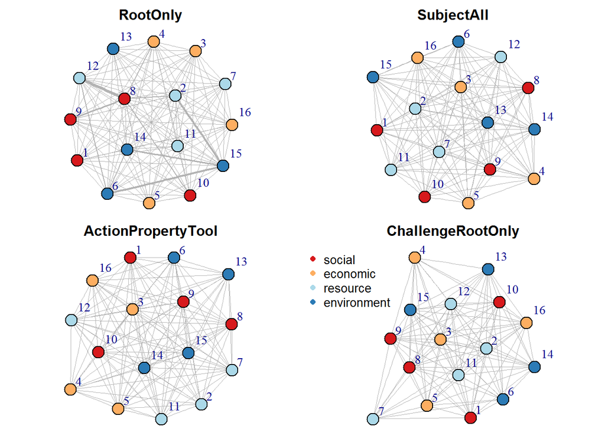

**Fig 1** Four categories of goal level networks, characterized by the subjects they address (SubjectAll), the actions they propose (ActionPropertyTool) and the challenges they addressed (ChallengeRootOnly) and a combined network (RootOnly). Colors indicate general goal categories to which the targets belong - dark blue (environment), light blue (resources/environment), yellow (economic), red (social goals).

#### 6.0.0.2 TARGET-LEVEL NETWORKS

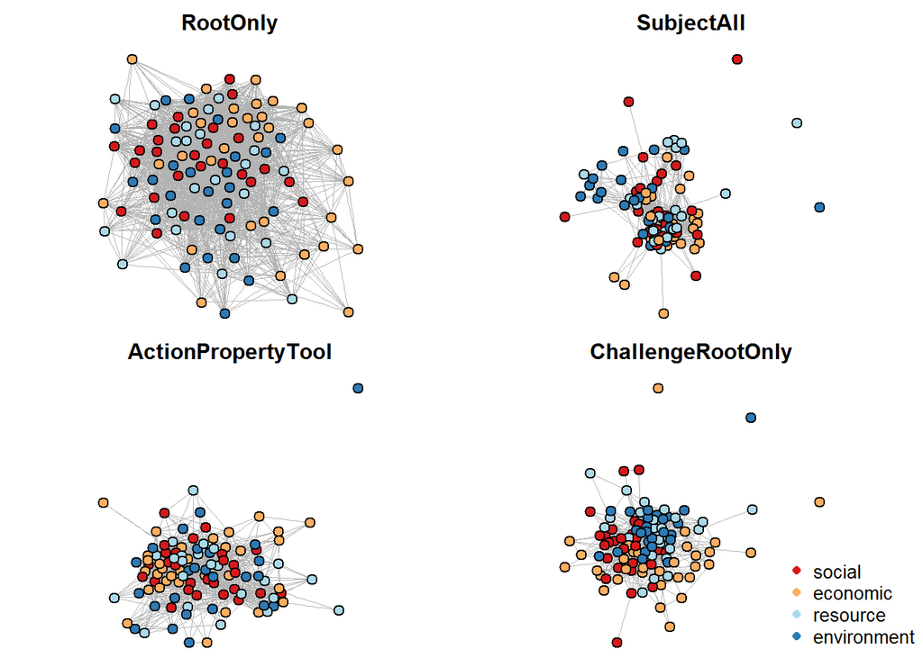

**Fig 2** Four categories of target level networks, characterized by the subjects they address (SubjectAll), the actions they propose (ActionPropertyTool) and the challenges they addressed (ChallengeRootOnly) and a combined network (RootOnly). Colors indicate general goal categories to which the targets belong - dark blue (environment), light blue (resources/environment), yellow (economic), red (social goals).

#### 6.0.0.3 TOP FIVE CONNECTING TARGETS ACROSS GOALS

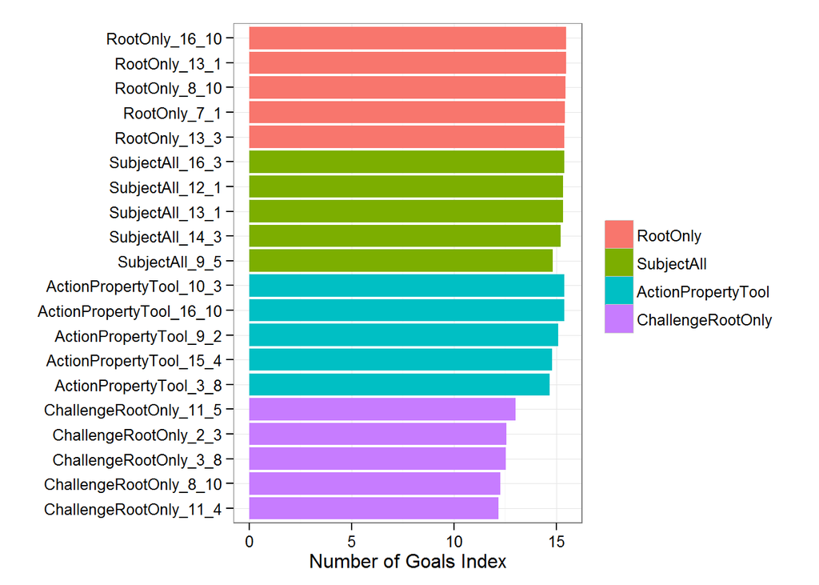

**Fig 3** The top five targets with regard to the number of goals they connected to (index: number of goals times proportion of cross-goal edges among all edges) across all keyword categories (red) and among the subjects addressed (green), the nature of the action (blue) and the challenges addressed (purple).

#### 6.0.0.4 TOP FIVE CONNECTING KEYWORDS ACROSS GOALS

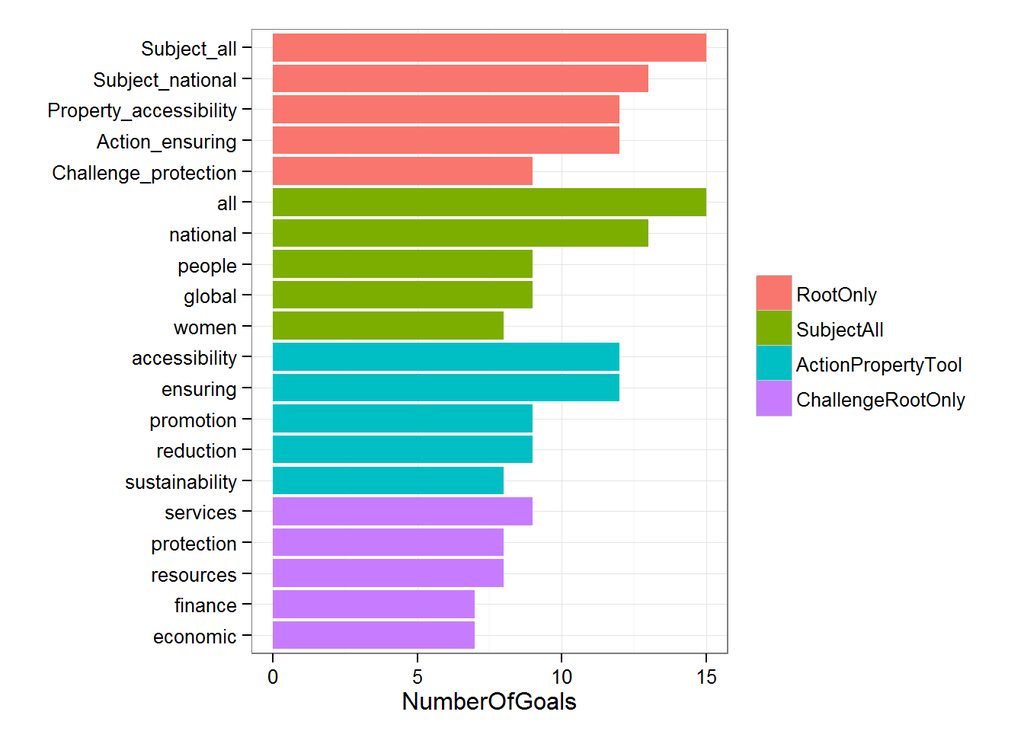

**Fig 4** Top keywords and the number of goals in which target texts they occur. The most common keywords across all categories (red) and among the subjects addressed (green), the nature of the action (blue) and the challenges addressed (purple).

#### 6.0.0.5 KEYWORD POSITIONS IN THE NETWORK

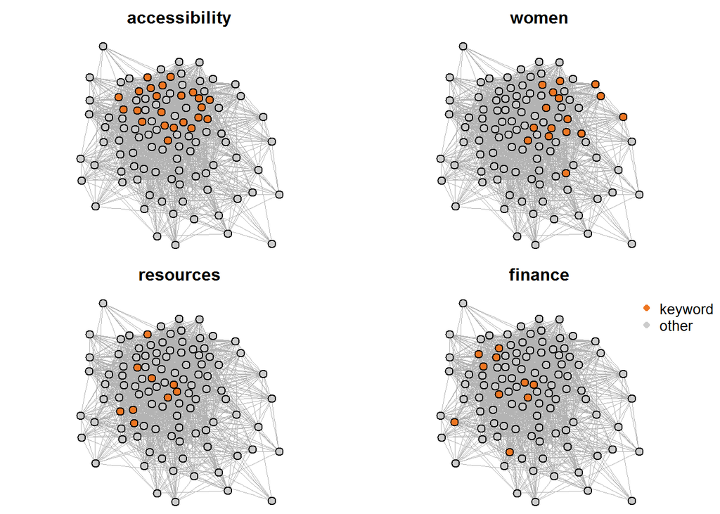

**Fig 5** The network positions of four of the top keywords found across a large number of goals. Keywords are visualized in the same target level network, note how they each cover different parts of the target network.

# 7 DISCUSSION

The analysis conducted in this paper, is to my knowledge the most detailed formal network analysis of the Sustainable Development Goals as a system of targets. While there is room to continue to advance application of network analysis to the SDGs, e.g. by including *means of implementation* targets, incorporating thesauruses to identify synonyms and implement a hierarchical analysis of keywords, the analysis provides a useful starting point for these more advanced applications and, more importantly, achieves a concise synthesis and helpful visualizations of the interconnections among more than 100 of the SDG targets.

The present analysis yields multiple novel insights to the SDGs a system of targets. First and foremost, I show that connections between targets and goals become increasingly evident when targets are characterized, not only by the topical challenges they address (which has dominated previous approaches), but also by the subjects they address and the nature of the actions they propose. Secondly and more specifically, this multifaceted analysis increases connections across genereal goal themes, and thus helps avoid treating the SDGs as a fragemented agenda of disparate social, economic, environmental and resource topics. Thirdly, the analysis identifies the central targets that are connected to targets under other goals and therefore require coordination with other planned actions. Fourth and finally, the analysis identifies a number of keyword topics that if addressed succesfully across targets will help achieve a high proportion of the SDGs, such as issues of access, women, resources and finance.

**Usefulness of subject and character categories**. Only viewing targets by their immediate challenges risk missing important leverage points for coordination of e.g. government actions that reachc across ministries or agencies as well as cross-disciplinary research that requires interdisciplinary coordination. *Challenge* networks in general show the highest level of assorting according to both general goal themes (social, economic, ressource and environment) as well as individual goals. This is because goals have been constructed to reflect the main challenge they address (e.g. climate, inequality, health etc.). Adding *subject* and *character* to the keyword mapping is one way of identifying e.g. the issues that certain countries need to prioritize or issues that are aimed at certain groups of e.g. vulnerable groups such as children. This idea is supported by the fact that *subject* and *character* networks in general have much lower assortativity scores, in particular for the four goal themes (**table 2 and 4**).

The issue of increasing *access* to various resources and benefits is one of the most striking examples of an area that reaches across goals and would benefit from stakeholder coordination between both decision makers and researchers. The issue is found in 12 goals in networks based on goal 1 to 16.

**Comparing central goals and targets to LeBlanc** *Goal level networks*. Where Le Blanc’s thematic assesment finds that targets under goals on sustainable consumption (12), inequality (10), poverty (1) and economic growth (8) are thematically most connected to other goals (table 1 in Le Blanc 2015), the present goal-level network analysis show that when considering both *subjects*, *character* of the action, and the *challenge*, all goals are directly connected the rest of the goals (fig. 1, table 2). In fact, goal-level *challenge* based networks have some of the highest distance scores (table 2).

*Target level networks* Central goals can also be identified as goals containing single targets that connect to targets under a large proportion of the remaining goals. Identifying central goals based on single targets, should be less prone to artifially rank the goals with the most targets (and likely most cross-goal connections) as the most central. When this is done for the *challenge* based network, goals on cities (11), hunger (2), health (3) and economic growth (8) are identified as the goals containing the most central targets. In comparison to LeBlanc’s analysis only the goal on economic growth (8) ranks in top four in both analyses. When we expand this approach to all keyword categories, goals on peace (16), climate (13, with two targets), economic growth (8) and energy (7), are ranked as the four most central goals. Again, sharing only the goal on economic growth (8) with Le Blanc’s analysis and interestingly containing both goals from the social (16), economic (8), resource (7) and environmental (13) goal themes. These differences highlights the importance of distinguishing between important goals based on their entire set of targets, or a single target, and between central goals based only on *challenges* or a more complete set of characterisics, including *subjects* and the *character* of the actions.

**Targets that contain multiple top kewords link the network together** Only focusing on the (non-trivial) issues that sit central in the target network, such as *accesibility*, will risk loosing focus on he more peripheral parts of the target network. One strategy for achieving both at the same time is to identify central targets that link together different peripheries through co-occurrence of top keywords. This can be done, for example by using simple visualization techniques (fig. 5). Top keywords such as *women*, *resources* and *finance* all have a low degree of overlap among tagets (fig. 5), but cover both central and complementary peripheries. In figure 5 it is illustrated that these keywords co-occur in multiple of the centrally placed targets.

**Perspectives and conclusion**. Future analyses would benefit from expanding on the methodology presented here,for example by better reflecting whether keywords are mentioned among a host of examples or as the only keyword of that type in a given target text. This type of mapping could be used to give larger weight to the latter case in the network analysis.

The results presented here complement previous studies looking at the SGDs as an interconnected system. In particular, the present study advances previous approaches by analyzing target to target linkages, composed of more than 2200 unique keyword mappings and keyword type combinations, providing a new level of detail and a new perspective on the SDGs.

# 8 REFERENCES

- Carroll and Jørgensen et al. (2014). Applying evolutionary biology to address global challenges. Science.
- Cutter, A. (2015) Sustainable Development Goals and integration: Achieving a better balance between the economic, social and environmental dimensions. Report.
- Griggs et al. (2014a) Sustainable development goals for people and planet. Nature.
- Griggs et al. (2014b) An integrated framework for sustainable development goals. Ecology and Society.
- Haijer et al. (2015) Beyond cockpit-ism. Four insights to enhance the transformative poential of the Sustainable Development Goals. Sustainability.
- ICSU, ISSC (2015): Review of the Sustainable Development Goals: The Science Perspective. Paris: International Council for Science (ICSU).
- Le Blanc, D. (2015a) Towards Integration at Last? The Sustainable Development Goals as a Network of Targets. DESA Working Paper No. 141. ST/ESA/2015/DWP/141.
- Le Blanc, D. (2015b) Towards Integration at Last? The Sustainable Development Goals as a Network of Targets. Sustainable development. DOI:10.1002/sd.1582
- Lu et al. (2015) Policy: Five priorities for the UN Sustainable Development Goals. Nature